# Desenvolvendo um modelo preditivo para estimar as emissões de CO2 pelos automóveis

Rafael

2023-05-05

À medida que a população mundial continua a crescer, o uso de automóveis tornou-se uma parte essencial da vida moderna. No entanto, as emissões que os automóveis produzem tornaram-se uma grande preocupação para cientistas e formuladores de políticas. O dióxido de carbono (CO2) é um dos principais gases produzidos pelos automóveis e é conhecido por ter um impacto significativo no meio ambiente.

Neste trabalho de pesquisa, é apresentado um modelo de regressão linear que analisa um banco de dados de automóveis de uma concessionária canadense para identificar as características dos automóveis que têm mais impacto nas emissões de CO2. Ao fazer isso, será possível fornecer aos formuladores de políticas e aos fabricantes de automóveis informações valiosas que possam ajudá-los a reduzir o impacto ambiental dos automóveis.

Ao final, teremos um modelo linear com transformação de Box-Cox que apresenta as emissões de CO2 como variável dependente e as varias características dos automóveis como variáveis independentes.

**Banco de dados utilizado:**  
[FuelConsumption (favor clicar com botão direito do mouse e selecionar abrir em nova aba/janela)](https://github.com/rafaelpd887/DSPortfolio/blob/main/CO2Emissions/FuelConsumption.csv)

| Código | Combustível |
| --- | --- |
| D | Diesel |
| E | Etanol |
| X | Gasolina |
| Z | Gasolina Premium |

| Código | Transmissão |
| --- | --- |
| A | Automática |
| AM | Manual Automática |
| AS | Automática Sequencial |
| AV | Automática de Variação Contínua |
| M | Manual |

# Carregando os pacotes necessários

```r
pacotes <- c("kableExtra", "utils", "plotly", "dplyr", "rstatix", "jtools", "equatiomatic", "cowplot", "olsrr", "nortest", "car", "PerformanceAnalytics", "fastDummies", "ggplot2")
lapply(pacotes, library, character.only = TRUE)
```

# Carregando e salvando o banco de dados no R

```r
FuelConsumption <- read.csv("FuelConsumption.csv")
save(FuelConsumption, file = "FuelConsumption.RData")
```

# Analise inicial das variáveis

```r
View(FuelConsumption)
```

| MODELYEAR | MAKE | MODEL | VEHICLECLASS | ENGINESIZE | CYLINDERS | TRANSMISSION | FUELTYPE | FUELCONSUMPTION_CITY | FUELCONSUMPTION_HWY | FUELCONSUMPTION_COMB | FUELCONSUMPTION_COMB_MPG | CO2EMISSIONS |
| --- | --- | --- | --- | --- | --- | --- | --- | --- | --- | --- | --- | --- |
| 2014 | ACURA | ILX | COMPACT | 2.0 | 4 | AS5 | Z | 9.9 | 6.7 | 8.5 | 33 | 196 |
| 2014 | ACURA | ILX | COMPACT | 2.4 | 4 | M6 | Z | 11.2 | 7.7 | 9.6 | 29 | 221 |
| 2014 | ACURA | ILX HYBRID | COMPACT | 1.5 | 4 | AV7 | Z | 6.0 | 5.8 | 5.9 | 48 | 136 |
| 2014 | ACURA | MDX 4WD | SUV - SMALL | 3.5 | 6 | AS6 | Z | 12.7 | 9.1 | 11.1 | 25 | 255 |
| 2014 | ACURA | RDX AWD | SUV - SMALL | 3.5 | 6 | AS6 | Z | 12.1 | 8.7 | 10.6 | 27 | 244 |
| 2014 | ACURA | RLX | MID-SIZE | 3.5 | 6 | AS6 | Z | 11.9 | 7.7 | 10.0 | 28 | 230 |
| 2014 | ACURA | TL | MID-SIZE | 3.5 | 6 | AS6 | Z | 11.8 | 8.1 | 10.1 | 28 | 232 |
| 2014 | ACURA | TL AWD | MID-SIZE | 3.7 | 6 | AS6 | Z | 12.8 | 9.0 | 11.1 | 25 | 255 |
| 2014 | ACURA | TL AWD | MID-SIZE | 3.7 | 6 | M6 | Z | 13.4 | 9.5 | 11.6 | 24 | 267 |
| 2014 | ACURA | TSX | COMPACT | 2.4 | 4 | AS5 | Z | 10.6 | 7.5 | 9.2 | 31 | 212 |

A variável MODELYEAR, que representa o ano de fabricação do automóvel, possui o mesmo valor em todas as observações(o banco de dados completo pode ser visualizado no link disponibilizado no inicio deste documento). Logo, podemos constatar o que a mesma não terá influencia no modelo e ocasionará em um aumento inútil da quantidade de dados a serem processados. Por esse motivo, vamos eliminá-la do nosso banco de dados.

```r
dropyear <- FuelConsumption[-c(1)]
```

Além disso, é possível perceber também que a variável MODEL possui níveis que muito pouco se repetem nas 1067 observações. Consequentemente, a variável não consegue formar padrões ou tendências significativas que possam ajudar o modelo a fazer previsões ou inferências precisas. Assim sendo, também iremos eliminar essa variável.

```r
dropyear2 <- dropyear[-c(2)]
```

Visualizando o novo banco de dados:

```r
View(dropyear2)
```

| MAKE | VEHICLECLASS | ENGINESIZE | CYLINDERS | TRANSMISSION | FUELTYPE | FUELCONSUMPTION_CITY | FUELCONSUMPTION_HWY | FUELCONSUMPTION_COMB | FUELCONSUMPTION_COMB_MPG | CO2EMISSIONS |
| --- | --- | --- | --- | --- | --- | --- | --- | --- | --- | --- |
| ACURA | COMPACT | 2.0 | 4 | AS5 | Z | 9.9 | 6.7 | 8.5 | 33 | 196 |
| ACURA | COMPACT | 2.4 | 4 | M6 | Z | 11.2 | 7.7 | 9.6 | 29 | 221 |
| ACURA | COMPACT | 1.5 | 4 | AV7 | Z | 6.0 | 5.8 | 5.9 | 48 | 136 |
| ACURA | SUV - SMALL | 3.5 | 6 | AS6 | Z | 12.7 | 9.1 | 11.1 | 25 | 255 |
| ACURA | SUV - SMALL | 3.5 | 6 | AS6 | Z | 12.1 | 8.7 | 10.6 | 27 | 244 |
| ACURA | MID-SIZE | 3.5 | 6 | AS6 | Z | 11.9 | 7.7 | 10.0 | 28 | 230 |
| ACURA | MID-SIZE | 3.5 | 6 | AS6 | Z | 11.8 | 8.1 | 10.1 | 28 | 232 |
| ACURA | MID-SIZE | 3.7 | 6 | AS6 | Z | 12.8 | 9.0 | 11.1 | 25 | 255 |
| ACURA | MID-SIZE | 3.7 | 6 | M6 | Z | 13.4 | 9.5 | 11.6 | 24 | 267 |
| ACURA | COMPACT | 2.4 | 4 | AS5 | Z | 10.6 | 7.5 | 9.2 | 31 | 212 |

# Visualizando e alterando o tipo das variáveis

```r
glimpse(dropyear2)
```

```
## Rows: 1,067
## Columns: 11
## $ MAKE                     <chr> "ACURA", "ACURA", "ACURA", "ACURA", "ACURA", …
## $ VEHICLECLASS             <chr> "COMPACT", "COMPACT", "COMPACT", "SUV - SMALL…
## $ ENGINESIZE               <dbl> 2.0, 2.4, 1.5, 3.5, 3.5, 3.5, 3.5, 3.7, 3.7, …
## $ CYLINDERS                <int> 4, 4, 4, 6, 6, 6, 6, 6, 6, 4, 4, 6, 12, 12, 8…
## $ TRANSMISSION             <chr> "AS5", "M6", "AV7", "AS6", "AS6", "AS6", "AS6…
## $ FUELTYPE                 <chr> "Z", "Z", "Z", "Z", "Z", "Z", "Z", "Z", "Z", …
## $ FUELCONSUMPTION_CITY     <dbl> 9.9, 11.2, 6.0, 12.7, 12.1, 11.9, 11.8, 12.8,…
## $ FUELCONSUMPTION_HWY      <dbl> 6.7, 7.7, 5.8, 9.1, 8.7, 7.7, 8.1, 9.0, 9.5, …
## $ FUELCONSUMPTION_COMB     <dbl> 8.5, 9.6, 5.9, 11.1, 10.6, 10.0, 10.1, 11.1, …
## $ FUELCONSUMPTION_COMB_MPG <int> 33, 29, 48, 25, 27, 28, 28, 25, 24, 31, 29, 2…
## $ CO2EMISSIONS             <int> 196, 221, 136, 255, 244, 230, 232, 255, 267, …
```

Aqui podemos ver que algumas das variáveis estão tipificadas como “intenger”. Como algumas funções a serem usadas durante esta modelagem exigem que as variáveis sejam do tipo “numeric”, vamos alterar o tipo das variáveis “intenger” para “numeric”.

```r
FuelConsumption$CYLINDERS <- as.numeric(dropyear$CYLINDERS)
FuelConsumption$FUELCONSUMPTION_COMB_MPG <- as.numeric(dropyear$FUELCONSUMPTION_COMB_MPG)
FuelConsumption$CO2EMISSIONS <- as.numeric(dropyear$CO2EMISSIONS)
```

```r
glimpse(dropyear)
```

```
## Rows: 1,067
## Columns: 12
## $ MAKE                     <chr> "ACURA", "ACURA", "ACURA", "ACURA", "ACURA", …
## $ MODEL                    <chr> "ILX", "ILX", "ILX HYBRID", "MDX 4WD", "RDX A…
## $ VEHICLECLASS             <chr> "COMPACT", "COMPACT", "COMPACT", "SUV - SMALL…
## $ ENGINESIZE               <dbl> 2.0, 2.4, 1.5, 3.5, 3.5, 3.5, 3.5, 3.7, 3.7, …
## $ CYLINDERS                <int> 4, 4, 4, 6, 6, 6, 6, 6, 6, 4, 4, 6, 12, 12, 8…
## $ TRANSMISSION             <chr> "AS5", "M6", "AV7", "AS6", "AS6", "AS6", "AS6…
## $ FUELTYPE                 <chr> "Z", "Z", "Z", "Z", "Z", "Z", "Z", "Z", "Z", …
## $ FUELCONSUMPTION_CITY     <dbl> 9.9, 11.2, 6.0, 12.7, 12.1, 11.9, 11.8, 12.8,…
## $ FUELCONSUMPTION_HWY      <dbl> 6.7, 7.7, 5.8, 9.1, 8.7, 7.7, 8.1, 9.0, 9.5, …
## $ FUELCONSUMPTION_COMB     <dbl> 8.5, 9.6, 5.9, 11.1, 10.6, 10.0, 10.1, 11.1, …
## $ FUELCONSUMPTION_COMB_MPG <int> 33, 29, 48, 25, 27, 28, 28, 25, 24, 31, 29, 2…
## $ CO2EMISSIONS             <int> 196, 221, 136, 255, 244, 230, 232, 255, 267, …
```

# Estatísticas das variáveis

```r
summary(FuelConsumption)
```

```
##    MODELYEAR        MAKE              MODEL           VEHICLECLASS
##  Min.   :2014   Length:1067        Length:1067        Length:1067
##  1st Qu.:2014   Class :character   Class :character   Class :character
##  Median :2014   Mode  :character   Mode  :character   Mode  :character
##  Mean   :2014
##  3rd Qu.:2014
##  Max.   :2014
##    ENGINESIZE      CYLINDERS      TRANSMISSION         FUELTYPE
##  Min.   :1.000   Min.   : 3.000   Length:1067        Length:1067
##  1st Qu.:2.000   1st Qu.: 4.000   Class :character   Class :character
##  Median :3.400   Median : 6.000   Mode  :character   Mode  :character
##  Mean   :3.346   Mean   : 5.795
##  3rd Qu.:4.300   3rd Qu.: 8.000
##  Max.   :8.400   Max.   :12.000
##  FUELCONSUMPTION_CITY FUELCONSUMPTION_HWY FUELCONSUMPTION_COMB
##  Min.   : 4.60        Min.   : 4.900      Min.   : 4.70
##  1st Qu.:10.25        1st Qu.: 7.500      1st Qu.: 9.00
##  Median :12.60        Median : 8.800      Median :10.90
##  Mean   :13.30        Mean   : 9.475      Mean   :11.58
##  3rd Qu.:15.55        3rd Qu.:10.850      3rd Qu.:13.35
##  Max.   :30.20        Max.   :20.500      Max.   :25.80
##  FUELCONSUMPTION_COMB_MPG  CO2EMISSIONS
##  Min.   :11.00            Min.   :108.0
##  1st Qu.:21.00            1st Qu.:207.0
##  Median :26.00            Median :251.0
##  Mean   :26.44            Mean   :256.2
##  3rd Qu.:31.00            3rd Qu.:294.0
##  Max.   :60.00            Max.   :488.0
```

Categorias das variáveis categóricas:

```r
levels(factor(FuelConsumption$MAKE))
```

```
##  [1] "ACURA"         "ASTON MARTIN"  "AUDI"          "BENTLEY"
##  [5] "BMW"           "BUICK"         "CADILLAC"      "CHEVROLET"
##  [9] "CHRYSLER"      "DODGE"         "FIAT"          "FORD"
## [13] "GMC"           "HONDA"         "HYUNDAI"       "INFINITI"
## [17] "JAGUAR"        "JEEP"          "KIA"           "LAMBORGHINI"
## [21] "LAND ROVER"    "LEXUS"         "LINCOLN"       "MASERATI"
## [25] "MAZDA"         "MERCEDES-BENZ" "MINI"          "MITSUBISHI"
## [29] "NISSAN"        "PORSCHE"       "RAM"           "ROLLS-ROYCE"
## [33] "SCION"         "SMART"         "SRT"           "SUBARU"
## [37] "TOYOTA"        "VOLKSWAGEN"    "VOLVO"
```

```r
levels(factor(FuelConsumption$VEHICLECLASS))
```

```
##  [1] "COMPACT"                  "FULL-SIZE"
##  [3] "MID-SIZE"                 "MINICOMPACT"
##  [5] "MINIVAN"                  "PICKUP TRUCK - SMALL"
##  [7] "PICKUP TRUCK - STANDARD"  "SPECIAL PURPOSE VEHICLE"
##  [9] "STATION WAGON - MID-SIZE" "STATION WAGON - SMALL"
## [11] "SUBCOMPACT"               "SUV - SMALL"
## [13] "SUV - STANDARD"           "TWO-SEATER"
## [15] "VAN - CARGO"              "VAN - PASSENGER"
```

```r
levels(factor(FuelConsumption$TRANSMISSION))
```

```
##  [1] "A4"  "A5"  "A6"  "A7"  "A8"  "A9"  "AM5" "AM6" "AM7" "AS4" "AS5" "AS6"
## [13] "AS7" "AS8" "AS9" "AV"  "AV6" "AV7" "AV8" "M5"  "M6"  "M7"
```

```r
levels(factor(FuelConsumption$FUELTYPE))
```

```
## [1] "D" "E" "X" "Z"
```

Frequencia das variáveis categóricas:

```r
table(FuelConsumption$MAKE)
```

```
##
##         ACURA  ASTON MARTIN          AUDI       BENTLEY           BMW
##            12             7            49             8            64
##         BUICK      CADILLAC     CHEVROLET      CHRYSLER         DODGE
##            16            32            86            19            39
##          FIAT          FORD           GMC         HONDA       HYUNDAI
##            10            90            49            21            24
##      INFINITI        JAGUAR          JEEP           KIA   LAMBORGHINI
##            21            22            31            33             3
##    LAND ROVER         LEXUS       LINCOLN      MASERATI         MAZDA
##            19            22            11             6            27
## MERCEDES-BENZ          MINI    MITSUBISHI        NISSAN       PORSCHE
##            59            36            16            33            44
##           RAM   ROLLS-ROYCE         SCION         SMART           SRT
##            13             7             9             2             2
##        SUBARU        TOYOTA    VOLKSWAGEN         VOLVO
##            23            49            42            11
```

```r
table(FuelConsumption$VEHICLECLASS)
```

```
##
##                  COMPACT                FULL-SIZE                 MID-SIZE
##                      172                       86                      178
##              MINICOMPACT                  MINIVAN     PICKUP TRUCK - SMALL
##                       47                       14                       12
##  PICKUP TRUCK - STANDARD  SPECIAL PURPOSE VEHICLE STATION WAGON - MID-SIZE
##                       62                        7                        6
##    STATION WAGON - SMALL               SUBCOMPACT              SUV - SMALL
##                       36                       65                      154
##           SUV - STANDARD               TWO-SEATER              VAN - CARGO
##                      110                       71                       22
##          VAN - PASSENGER
##                       25
```

```r
table(FuelConsumption$TRANSMISSION)
```

```
##
##  A4  A5  A6  A7  A8  A9 AM5 AM6 AM7 AS4 AS5 AS6 AS7 AS8 AS9  AV AV6 AV7 AV8  M5
##  45  30 222  12  87   8   2   6  34   1  10 189  76  80   2  46  11   5   3  48
##  M6  M7
## 141   9
```

```r
table(FuelConsumption$FUELTYPE)
```

```
##
##   D   E   X   Z
##  27  92 514 434
```

# Verificando as correlações entre as variáveis numéricas a serem utilizadas

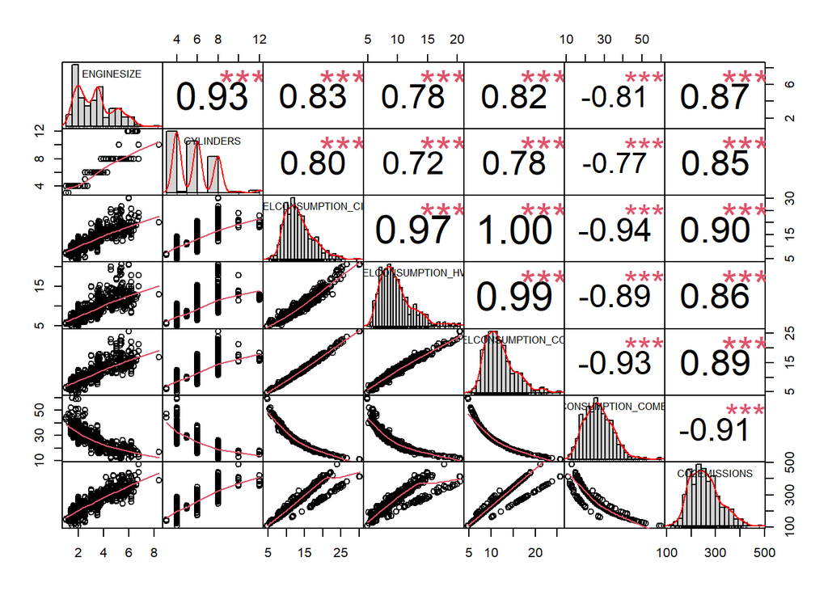

```r
chart.Correlation((FuelConsumption[, c(5, 6, 9:13)]), histogram = TRUE)
```

*enginesize, cylinders, fuelconsumption_city, fuelcomsumption_hwy, fuelconsumption_comb, fuelconsumption_comb_mpg, co2emissions*

Como era de se esperar, as variáveis referentes ao consumo de combustível possuem alto grau de correlação entre si, pois ambas estão relacionadas ao consumo de combustível em diferentes contextos de direção. Se há um aumento no consumo de combustível na cidade, é provável que haja um aumento correspondente no consumo de combustível na estrada, e vice-versa. Essa relação positiva entre as duas variáveis resulta em um alto grau de correlação entre elas. Este é um típico exemplo de colinearidade que vamos resolver através do algoritmo de stepwise para evitar problemas no modelo final.

# Dummização das variáveis categóricas

Antes de prosseguirmos, precisamos converter nossas variáveis categóricas para valores numéricos. Para tal, utilizaremos o processo de dummização, também conhecido por codificação one-hot. Neste caso, será usada a categoria mais frequente de cada variável categórica como referência para a estimação dos valores dos parâmetros das variáveis dummies. A frequência dessas variáveis pode ser conferida logo acima em “Estatísticas das variáveis”.

```r
FuelConsumption_dummies <- dummy_columns(.data = dropyear2,
                                    select_columns = "MAKE",
                                    remove_selected_columns = T,
                                    remove_most_frequent_dummy = T)

FuelConsumption_dummies <- dummy_columns(.data = FuelConsumption_dummies,
                                         select_columns = "VEHICLECLASS",
                                         remove_selected_columns = T,
                                         remove_most_frequent_dummy = T)

FuelConsumption_dummies <- dummy_columns(.data = FuelConsumption_dummies,
                                         select_columns = "TRANSMISSION",
                                         remove_selected_columns = T,
                                         remove_most_frequent_dummy = T)

FuelConsumption_dummies <- dummy_columns(.data = FuelConsumption_dummies,
                                         select_columns = "FUELTYPE",
                                         remove_selected_columns = T,
                                         remove_most_frequent_dummy = T)
```

Com as variáveis categóricas dummizadas, podemos começar a criar o nosso modelo.

# Modelando

```r
modelo_FuelConsumption <- lm(formula = CO2EMISSIONS ~ ., data = FuelConsumption_dummies)
```

Agora que temos o nosso primeiro modelo, podemos executar o algorítmo de Stepwise no mesmo através da função `step`:

```r
step_FuelConsumption <- step(modelo_FuelConsumption, k = qchisq(p = 0.05, df = 1, lower.tail = FALSE))
```

*o valor “k” é usado como um limite crítico para a estatística qui-quadrado, e nesse caso estamos buscando uma seleção de variáveis com um nível de confiança de 95%.*

Vamos usar a função `summary` para avaliar os parâmetros do nosso modelo:

```r
summary(step_FuelConsumption)
```

```
##
## Call:
## lm(formula = CO2EMISSIONS ~ CYLINDERS + FUELCONSUMPTION_COMB +
##     FUELCONSUMPTION_COMB_MPG + MAKE_BMW + MAKE_PORSCHE + VEHICLECLASS_COMPACT +
##     `VEHICLECLASS_PICKUP TRUCK - STANDARD` + `VEHICLECLASS_SUV - STANDARD` +
##     `VEHICLECLASS_TWO-SEATER` + TRANSMISSION_AV + FUELTYPE_D +
##     FUELTYPE_E, data = FuelConsumption_dummies)
##
## Residuals:
##     Min      1Q  Median      3Q     Max
## -23.290  -2.161  -0.691   0.938  38.633
##
## Coefficients:
##                                          Estimate Std. Error  t value Pr(>|t|)
## (Intercept)                              86.42465    3.53340   24.459  < 2e-16
## CYLINDERS                                 1.70864    0.17206    9.930  < 2e-16
## FUELCONSUMPTION_COMB                     17.93986    0.17884  100.310  < 2e-16
## FUELCONSUMPTION_COMB_MPG                 -1.49883    0.06918  -21.665  < 2e-16
## MAKE_BMW                                 -2.47424    0.71285   -3.471  0.00054
## MAKE_PORSCHE                             -2.47898    0.84606   -2.930  0.00346
## VEHICLECLASS_COMPACT                      1.25355    0.48312    2.595  0.00960
## `VEHICLECLASS_PICKUP TRUCK - STANDARD`    2.27570    0.74216    3.066  0.00222
## `VEHICLECLASS_SUV - STANDARD`             1.51029    0.58230    2.594  0.00963
## `VEHICLECLASS_TWO-SEATER`                 1.52927    0.68209    2.242  0.02517
## TRANSMISSION_AV                           2.71432    0.89150    3.045  0.00239
## FUELTYPE_D                               32.92162    1.09034   30.194  < 2e-16
## FUELTYPE_E                             -110.37148    0.88755 -124.356  < 2e-16
##
## (Intercept)                            ***
## CYLINDERS                              ***
## FUELCONSUMPTION_COMB                   ***
## FUELCONSUMPTION_COMB_MPG               ***
## MAKE_BMW                               ***
## MAKE_PORSCHE                           **
## VEHICLECLASS_COMPACT                   **
## `VEHICLECLASS_PICKUP TRUCK - STANDARD` **
## `VEHICLECLASS_SUV - STANDARD`          **
## `VEHICLECLASS_TWO-SEATER`              *
## TRANSMISSION_AV                        **
## FUELTYPE_D                             ***
## FUELTYPE_E                             ***
## ---
## Signif. codes:  0 '***' 0.001 '**' 0.01 '*' 0.05 '.' 0.1 ' ' 1
##
## Residual standard error: 5.355 on 1054 degrees of freedom
## Multiple R-squared:  0.9929, Adjusted R-squared:  0.9929
## F-statistic: 1.236e+04 on 12 and 1054 DF,  p-value: < 2.2e-16
```

Podemos ver que a função `step` manteve as variáveis “fuelconsumption_comb” e “fuelconsumption_comb_mpg” apesar da alta correlação entre as duas apontada na tabela de correlação. Vamos verificar os valores dos fatores de inflação da variância usando a funçao `vif`.

```r
vif(step_FuelConsumption)
```

```
##                              CYLINDERS                   FUELCONSUMPTION_COMB
##                               3.556295                              14.448422
##               FUELCONSUMPTION_COMB_MPG                               MAKE_BMW
##                               9.925956                               1.066287
##                           MAKE_PORSCHE                   VEHICLECLASS_COMPACT
##                               1.053243                               1.174497
## `VEHICLECLASS_PICKUP TRUCK - STANDARD`          `VEHICLECLASS_SUV - STANDARD`
##                               1.121868                               1.166800
##              `VEHICLECLASS_TWO-SEATER`                        TRANSMISSION_AV
##                               1.075468                               1.220163
##                             FUELTYPE_D                             FUELTYPE_E
##                               1.091233                               2.309771
```

Sabendo que valores muito acima de 1 indicam presença de colinearidade, podemos assumir que “fuelconsumption_comb” e “fuelconsumption_comb_mpg” possuem uma alta colinearidade. Como a alta colinearidade pode ser prejudicial ao modelo, vamos eliminar a variável com o maior VIF apresentado para evitar a multicolinearidade.

```r
step_FuelConsumption2 <- update(step_FuelConsumption, CO2EMISSIONS ~ .- FUELCONSUMPTION_COMB, data = FuelConsumption_dummies)
```

Olhando os novos valores de VIF:

```r
vif(step_FuelConsumption2)
```

```
##                              CYLINDERS               FUELCONSUMPTION_COMB_MPG
##                               2.766158                               3.880821
##                               MAKE_BMW                           MAKE_PORSCHE
##                               1.053868                               1.033862
##                   VEHICLECLASS_COMPACT `VEHICLECLASS_PICKUP TRUCK - STANDARD`
##                               1.174482                               1.121858
##          `VEHICLECLASS_SUV - STANDARD`              `VEHICLECLASS_TWO-SEATER`
##                               1.163437                               1.073321
##                        TRANSMISSION_AV                             FUELTYPE_D
##                               1.194467                               1.091230
##                             FUELTYPE_E
##                               1.340661
```

Podemos ver que os valores reduziram consideravelmente. Vamos usar a função `step` no novo modelo e então iremos testar se o mesmo apresenta heterocedasticidade, presença de variância não constante nos resíduos de um modelo, e se seus resíduos são aderentes à normalidade. Vamos usar, respectivamente, os testes de Breusch-Pagan(`ols_test_breusch_pagan`) e Shapiro-Francia(`sf.test`) para tal.

```r
step_FuelConsumption3 <- step(step_FuelConsumption2, k = 3.841459)
```

*o valor “k” é usado como um limite crítico para a estatística qui-quadrado, e nesse caso estamos buscando uma seleção de variáveis com um nível de confiança de 95%.*

```r
ols_test_breusch_pagan(step_FuelConsumption3)
```

```
##
##  Breusch Pagan Test for Heteroskedasticity
##  -----------------------------------------
##  Ho: the variance is constant
##  Ha: the variance is not constant
##
##                   Data
##  ----------------------------------------
##  Response : CO2EMISSIONS
##  Variables: fitted values of CO2EMISSIONS
##
##          Test Summary
##  -------------------------------
##  DF            =    1
##  Chi2          =    99.15354
##  Prob > Chi2   =    2.336652e-23
```

```r
sf.test(step_FuelConsumption3$residuals)
```

```
##
##  Shapiro-Francia normality test
##
## data:  step_FuelConsumption3$residuals
## W = 0.88059, p-value < 2.2e-16
```

Pelos resultados apresentados pelos testes, é possível concluir que o atual modelo possui uma variância heterocedastica em seus resíduos, pois o valor-p (2.336652e-23) é menor do que o nível de significância comumente utilizado de 0,05. Podemos concluir também que os resíduos parecem não seguir uma distribuição normal, já que o valor-p (2.2e-16) também é menor do que o nível de significância de 0,05. Apesar de um modelo com essas características ainda possuir potencial preditivo, tais características podem indicar que o modelo ainda possa ser aprimorado. Tentaremos aprimorar a capacidade preditiva do nosso modelo através da transformação de Box-Cox na sua variável dependente.

# A transformação de Box-Cox

A transformação de Box-Cox é uma técnica estatística utilizada para estabilizar a variância e/ou aproximar a distribuição dos dados para uma distribuição normal. Portanto, ela pode nos auxiliar a reduzir a heterocedasticidade do modelo, e melhorar a aderência dos seus resíduos à normalidade. A transformação de Box-Cox é definida por uma equação paramétrica, onde um parâmetro lambda (λ) é aplicado aos dados. Vamos definir o valor de lambda (λ) para nossa variável dependente através da função `powerTransform` do pacote `car`.

```r
lambda_BC <- powerTransform(dropyear2$CO2EMISSIONS)
lambda_BC
```

```
## Estimated transformation parameter
## dropyear2$CO2EMISSIONS
##              0.1278504
```

Com o valor de lambda (λ) em mãos, nos resta executar a transformação da nossa variável dependente. Sabemos que a transformação a ser realizada varia de acordo com o valor de lambda (λ): *Se lambda for igual a 0, uma transformação logarítmica é aplicada aos dados.* Se lambda for diferente de 0, a transformação é dada pela fórmula: ((x^lambda) - 1) / lambda, onde x é o valor original dos dados. Como o nosso lambda (λ) é diferente de 0, basta executarmos o seguinte código para inserirmos a nossa variável dependente transformada no nosso banco de dados:

```r
FuelConsumption_dummies$bcCO2EMISSIONS <- (((dropyear2$CO2EMISSIONS ^ lambda_BC$lambda) - 1) / lambda_BC$lambda)
```

# Modelando com Box-Cox

Vamos estimar um novo modelando usando a variável dependente com transformação de Box-Cox:

```r
modelo_bc_FuelConsumption <- lm(formula = bcCO2EMISSIONS ~ .-CO2EMISSIONS,
                           data = FuelConsumption_dummies)
```

Visto que este é um novo modelo, precisamos executar novamente o algorítmo de Stepwise através da função `step` para eliminar variáveis não significativas.

```r
step_bc_FuelConsumption <- step(modelo_bc_FuelConsumption, k = 3.841459)
```

*o valor “k” é usado como um limite crítico para a estatística qui-quadrado, e nesse caso estamos buscando uma seleção de variáveis com um nível de confiança de 95%.*

Verificando os valores de VIF em nosso novo modelo:

```r
vif(step_bc_FuelConsumption)
```

```
##                              CYLINDERS                   FUELCONSUMPTION_CITY
##                               4.533626                             232.067828
##                   FUELCONSUMPTION_COMB               FUELCONSUMPTION_COMB_MPG
##                             226.916848                              12.118356
##                               MAKE_BMW                          MAKE_CHRYSLER
##                               1.055734                               1.085185
##                             MAKE_DODGE                              MAKE_MINI
##                               1.092760                               1.100341
##                        MAKE_MITSUBISHI    `VEHICLECLASS_PICKUP TRUCK - SMALL`
##                               1.483501                               1.075288
## `VEHICLECLASS_PICKUP TRUCK - STANDARD`          `VEHICLECLASS_SUV - STANDARD`
##                               1.298780                               1.352225
##         `VEHICLECLASS_VAN - PASSENGER`                        TRANSMISSION_A4
##                               1.614018                               1.572269
##                        TRANSMISSION_AV                       TRANSMISSION_AV6
##                               1.336003                               1.551947
##                        TRANSMISSION_M5                             FUELTYPE_D
##                               1.169629                               1.120641
##                             FUELTYPE_E
##                               2.739652
```

Como esperado, novamente as variáveis relacionadas ao consumo de combustível apresentam uma alta colinearidade. Nota-se também, que a função `step` não eliminou a variável “FUELCONSUMPTION_CITY” como havia eliminado no modelo sem a transformação de Box-Cox. Eliminaremos os valores mais altos de VIF para tentarmos garantir a eficácia preditiva do modelo:

```r
step_bc_FuelConsumption2 <- update(step_bc_FuelConsumption, bcCO2EMISSIONS ~ .- FUELCONSUMPTION_COMB - FUELCONSUMPTION_CITY, data = FuelConsumption_dummies)
```

Como as variáveis do nosso modelo foram alteradas, precisamos usar novamente a função `step`:

```r
step_bc_FuelConsumption3 <- step(step_bc_FuelConsumption2, k = 3.841459)
```

*o valor “k” é usado como um limite crítico para a estatística qui-quadrado, e nesse caso estamos buscando uma seleção de variáveis com um nível de confiança de 95%.*

Conferindo os novos valores de VIF:

```r
vif(step_bc_FuelConsumption3)
```

```
##                              CYLINDERS               FUELCONSUMPTION_COMB_MPG
##                               2.818367                               4.070345
##                               MAKE_BMW                          MAKE_CHRYSLER
##                               1.030173                               1.024935
##                             MAKE_DODGE                        MAKE_MITSUBISHI
##                               1.025345                               1.402096
##    `VEHICLECLASS_PICKUP TRUCK - SMALL` `VEHICLECLASS_PICKUP TRUCK - STANDARD`
##                               1.041477                               1.166559
##          `VEHICLECLASS_SUV - STANDARD`         `VEHICLECLASS_VAN - PASSENGER`
##                               1.222065                               1.221950
##                        TRANSMISSION_A4                        TRANSMISSION_AV
##                               1.202790                               1.182870
##                       TRANSMISSION_AV6                             FUELTYPE_D
##                               1.407417                               1.093097
##                             FUELTYPE_E
##                               1.386989
```

Com os valores de VIF consideravelmente reduzidos, podemos agora partir para os testes de Breusch-Pagan(`ols_test_breusch_pagan`) e Shapiro-Francia(`sf.test`). Vamos aproveitar também para avaliar os parâmetros do modelo usando `summary`:

```r
summary(step_bc_FuelConsumption3)
```

```
##
## Call:
## lm(formula = bcCO2EMISSIONS ~ CYLINDERS + FUELCONSUMPTION_COMB_MPG +
##     MAKE_BMW + MAKE_CHRYSLER + MAKE_DODGE + MAKE_MITSUBISHI +
##     `VEHICLECLASS_PICKUP TRUCK - SMALL` + `VEHICLECLASS_PICKUP TRUCK - STANDARD` +
##     `VEHICLECLASS_SUV - STANDARD` + `VEHICLECLASS_VAN - PASSENGER` +
##     TRANSMISSION_A4 + TRANSMISSION_AV + TRANSMISSION_AV6 + FUELTYPE_D +
##     FUELTYPE_E, data = FuelConsumption_dummies)
##
## Residuals:
##      Min       1Q   Median       3Q      Max
## -0.23102 -0.03972 -0.00660  0.03047  0.41212
##
## Coefficients:
##                                         Estimate Std. Error t value Pr(>|t|)
## (Intercept)                             9.324097   0.026732 348.793  < 2e-16
## CYLINDERS                               0.050369   0.002085  24.160  < 2e-16
## FUELCONSUMPTION_COMB_MPG               -0.059838   0.000603 -99.236  < 2e-16
## MAKE_BMW                               -0.036264   0.009537  -3.802 0.000151
## MAKE_CHRYSLER                          -0.052770   0.017080  -3.090 0.002057
## MAKE_DODGE                             -0.033871   0.012039  -2.813 0.004994
## MAKE_MITSUBISHI                         0.065187   0.021738   2.999 0.002775
## `VEHICLECLASS_PICKUP TRUCK - SMALL`     0.070783   0.021593   3.278 0.001079
## `VEHICLECLASS_PICKUP TRUCK - STANDARD`  0.054160   0.010301   5.258 1.76e-07
## `VEHICLECLASS_SUV - STANDARD`           0.058240   0.008111   7.180 1.32e-12
## `VEHICLECLASS_VAN - PASSENGER`          0.263238   0.016305  16.145  < 2e-16
## TRANSMISSION_A4                         0.102007   0.012175   8.379  < 2e-16
## TRANSMISSION_AV                         0.063111   0.011947   5.282 1.55e-07
## TRANSMISSION_AV6                       -0.076332   0.026205  -2.913 0.003656
## FUELTYPE_D                              0.288201   0.014853  19.403  < 2e-16
## FUELTYPE_E                             -0.475942   0.009361 -50.841  < 2e-16
##
## (Intercept)                            ***
## CYLINDERS                              ***
## FUELCONSUMPTION_COMB_MPG               ***
## MAKE_BMW                               ***
## MAKE_CHRYSLER                          **
## MAKE_DODGE                             **
## MAKE_MITSUBISHI                        **
## `VEHICLECLASS_PICKUP TRUCK - SMALL`    **
## `VEHICLECLASS_PICKUP TRUCK - STANDARD` ***
## `VEHICLECLASS_SUV - STANDARD`          ***
## `VEHICLECLASS_VAN - PASSENGER`         ***
## TRANSMISSION_A4                        ***
## TRANSMISSION_AV                        ***
## TRANSMISSION_AV6                       **
## FUELTYPE_D                             ***
## FUELTYPE_E                             ***
## ---
## Signif. codes:  0 '***' 0.001 '**' 0.01 '*' 0.05 '.' 0.1 ' ' 1
##
## Residual standard error: 0.07288 on 1051 degrees of freedom
## Multiple R-squared:  0.9791, Adjusted R-squared:  0.9788
## F-statistic:  3286 on 15 and 1051 DF,  p-value: < 2.2e-16
```

```r
ols_test_breusch_pagan(step_bc_FuelConsumption3)
```

```
##
##  Breusch Pagan Test for Heteroskedasticity
##  -----------------------------------------
##  Ho: the variance is constant
##  Ha: the variance is not constant
##
##                    Data
##  ------------------------------------------
##  Response : bcCO2EMISSIONS
##  Variables: fitted values of bcCO2EMISSIONS
##
##         Test Summary
##  ----------------------------
##  DF            =    1
##  Chi2          =    0.6508984
##  Prob > Chi2   =    0.4197917
```

```r
sf.test(step_bc_FuelConsumption3$residuals)
```

```
##
##  Shapiro-Francia normality test
##
## data:  step_bc_FuelConsumption3$residuals
## W = 0.93977, p-value < 2.2e-16
```

Pelos resultados apresentados, podemos concluir que foi obtido um modelo superior ao modelo cuja variável dependente não havia sofrido a transformação de Box-Cox. Temos um alto valor de R² e variáveis indepedentes com um nível de significância superior a 95%. O novo modelo também apresentou durante o teste `ols_test_breusch_pagan` um valor p maior que 0,05, indicando a ausência de heterocedasticidade. Contudo, apesar dos esforços, não foi possível ajustar os resíduos à normalidade, pois o valor p associado ao teste `sf.test` continua sendo menor que 0,05.

Entretanto, apesar da normalidade dos resíduos ser uma suposição comum em muitos modelos estatísticos, ela nem sempre é necessária para obter previsões precisas. Segundo Wilcox (1998), mesmo que os resíduos de uma regressão linear não sigam uma distribuição normal, as previsões podem ser precisas e os testes de hipótese ainda podem ter poder satisfatório, desde que outras suposições do modelo sejam atendidas. Podemos conferir a capacidade preditiva do nosso modelo pelo gráfico abaixo:

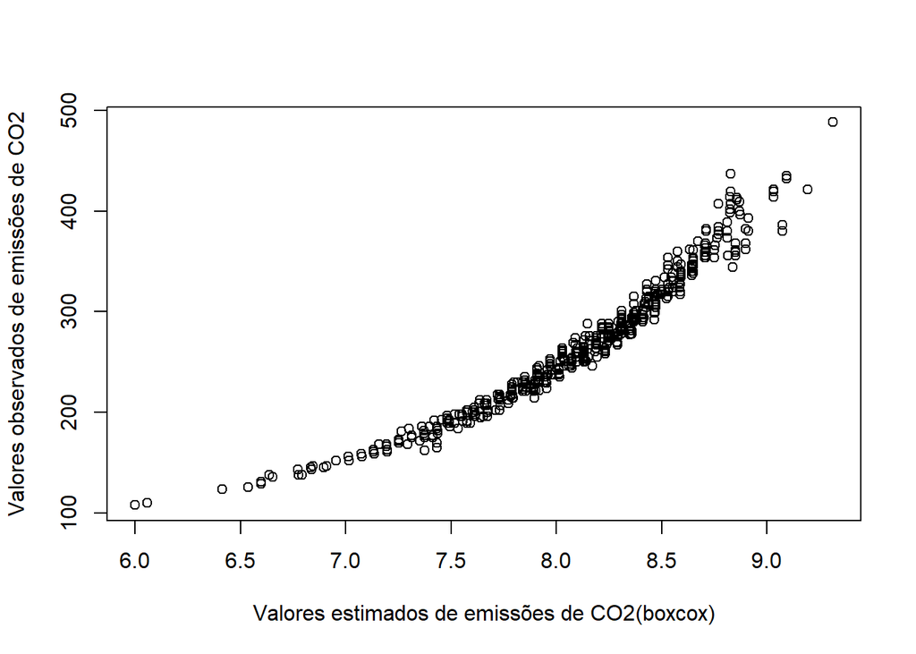

```r
FuelConsumption_dummies$fitted_step3 <- step_bc_FuelConsumption3$fitted.values
plot(FuelConsumption_dummies$CO2EMISSIONS ~ FuelConsumption_dummies$fitted_step3,
     xlab = "Valores estimados de emissões de CO2(boxcox)",
     ylab = "Valores observados de emissões de CO2")
```

Os valores resultantes do nosso modelo precisam passar por uma transformação inversa àquela feita durante a transformação de Box-Cox para que tenhamos os valores reais das emissões de CO2:

```r
((bcCO2EMISSIONS*(lambda_BC$lambda))+
    1)^(1/(lambda_BC$lambda))
```

# Modelo Final

$$\begin{aligned}
\operatorname{\widehat{bcCO2EMISSIONS}} &amp;= 9.32 +
0.05(\operatorname{CYLINDERS}) -
0.06(\operatorname{FUELCONSUMPTION\_COMB\_MPG}) -
0.04(\operatorname{MAKE\_BMW})\ - \\
&amp;\quad 0.05(\operatorname{MAKE\_CHRYSLER}) -
0.03(\operatorname{MAKE\_DODGE}) + 0.07(\operatorname{MAKE\_MITSUBISHI})
+ 0.07(\operatorname{`VEHICLECLASS\_PICKUP\ TRUCK\ -\ SMALL`})\ + \\
&amp;\quad 0.05(\operatorname{`VEHICLECLASS\_PICKUP\ TRUCK\ -\
STANDARD`}) + 0.06(\operatorname{`VEHICLECLASS\_SUV\ -\ STANDARD`}) +
0.26(\operatorname{`VEHICLECLASS\_VAN\ -\ PASSENGER`}) +
0.1(\operatorname{TRANSMISSION\_A4})\ + \\
&amp;\quad 0.06(\operatorname{TRANSMISSION\_AV}) -
0.08(\operatorname{TRANSMISSION\_AV6}) +
0.29(\operatorname{FUELTYPE\_D}) - 0.48(\operatorname{FUELTYPE\_E})
\end{aligned}$$

Os resultados da análise mostraram que o modelo final é uma ferramenta confiável e precisa para prever a quantidade de emissões de CO2 dos automóveis. O poder preditivo do modelo foi validado por sua capacidade de prever as emissões de CO2 de diferentes tipos de automóveis com alta precisão. Além disso, o modelo fornece informações valiosas sobre os fatores que influenciam as emissões de CO2, incluindo fabricante do automóvel, tipo de chassi do automóvel, tipo de combustível usado, tipo de transmissão e consumo combinado de combustível em milhas.

No geral, este documento demonstra o valor do uso de análises de dados e técnicas de modelagem estatística para abordar questões ambientais importantes. Pesquisas futuras podem se concentrar em expandir o modelo para incluir outros fatores que podem influenciar as emissões de CO2 e explorar o potencial do uso de algoritmos de aprendizado de máquina para melhorar a precisão e o poder preditivo do modelo.

# Referências

Wilcox, R. R. (1998). Do we really need the normality assumption for linear regression? The American Statistician, 52(2), 162-166.